# Chulwalhar Export Forecast -Unit10CaseStudy

Paola Leon, Eyal Greenberg and Kyle Killion

July 11, 2016

## Introduction

The prime minister of Chulwalhar has asked us to help him in forecasting exports from his country. In order to do this we have been given as-is data, which is the original or observed data, and planned data, which is what Chulwalhar would like to export. We also have a list of indicators that may affect exports. Our job is to find out the best way to forecast Chulwalhar’s exports in 2014 based on data collected before this year. In other words, we want to create a credible statistical model.

The export data for Chulwalhar are in two CSV files. One contains the as-is data and the other one contains the planned data. These data sets are also composed of other data sets: monthly and yearly for both groups. Your task is to take all of these data sets, import them into R, and develop a model to forecast the exports of these particular products for the prime minister of Chulwalhar.

Original data sources can be found in the link below:

https://s3-us-west-2.amazonaws.com/smu-mds/prod/MSDS+6306+Doing+Data+Science/Week+10/ChulwalarCase.zip

## Instructions

1. Submit an R markdown document with the code necessary to download, clean and analyze the data.
2. Interpretations of the code and analysis should be provided.
3. There should also be at least one graphic that explains an important feature of the data.
4. This graphic should be interpreted in the text of the document.

## Set the working directory

```r
setwd("/Users/paolaleon/Desktop/MSDS 6303 Doing Data Science/Unit10CaseStudy")
getwd()
```

```
## [1] "/Users/paolaleon/Desktop/MSDS 6303 Doing Data Science/Unit10CaseStudy"
```

## Download datasources.

1. Manually clicked in the link above and downloaded a .zip file name **ChulwalarCase.zip**
2. Manually unzipped the file and placed its contents under the working directory (in our local machine).
3. Using R, accessed the .csv files as follows:

```r
list.files()
```

```
##  [1] "ChulwalarCase.zip"
##  [2] "Chulwalhar Export Forecast -Unit10CaseStudy_html_files"
##  [3] "Chulwalhar Export Forecast -Unit10CaseStudy_html.html"
##  [4] "Chulwalhar Export Forecast -Unit10CaseStudy.pdf"
##  [5] "Forecasting Exports Chulwalar_0.8a.R"
##  [6] "ImportedAsIsDataChulwalar.csv"
##  [7] "ImportedIndicatorsChulwalar.csv"
##  [8] "ImportedPlanDataChulwalar.csv"
##  [9] "Instructions.txt"
## [10] "PLeon_EGreenberg_KKillion_Unit10CaseStudy.html"
## [11] "PLeon_EGreenberg_KKillion_Unit10CaseStudy.Rmd"
```

```r
rawImportedAsIsDataChulwalar <- read.csv("ImportedAsIsDataChulwalar.csv", sep = ";", stringsAsFactors=FALSE, header=TRUE)
rawImportedPlanDataChulwalar <- read.csv("ImportedPlanDataChulwalar.csv", sep = ";", stringsAsFactors=FALSE, header=TRUE)
rawImportedIndicatorsChulwalar <- read.csv("ImportedIndicatorsChulwalar.csv", sep = ";", stringsAsFactors=FALSE, header=TRUE)
```

## Analysis of raw data

1. General description of the dataframes: number of observations, number of variables, datatypes, and existance of NAs.

```r
str(rawImportedAsIsDataChulwalar)
```

```
## 'data.frame':    97 obs. of  8 variables:
##  $ Total.As.Is: chr  "Jan" "Feb" "Mar" "Apr" ...
##  $ X2008      : int  2313221 1950131 2346635 2039787 1756964 1458302 1679637 1639670 2882886 2959716 ...
##  $ X2009      : int  2610573 2371327 2743786 2125308 1850073 1836222 1797311 1851968 3271171 2818888 ...
##  $ X2010      : int  2760688 2918333 3227041 1613888 2550157 2317645 1474144 2148521 3898571 3348953 ...
##  $ X2011      : int  3112861 2926663 3294784 2577079 2774068 2378227 2222900 2991787 4151531 3318684 ...
##  $ X2012      : int  3093088 3679308 3433364 2714899 3011767 2726028 2483834 3055655 4200796 4228724 ...
##  $ X2013      : int  4119526 3535744 3560974 3760065 2959933 2787898 2828744 3084113 5107775 4562144 ...
##  $ X2014      : int  4308161 4155378 3924332 3659121 3898758 3313891 3595106 3502426 5619059 5274287 ...
```

```r
str(rawImportedPlanDataChulwalar)
```

```
## 'data.frame':    96 obs. of  8 variables:
##  $ Total.Plan: chr  "Jan" "Feb" "Mar" "Apr" ...
##  $ X2008     : int  2243103 2162705 2720911 2011182 1877757 1819924 1682196 1893171 3325711 2662148 ...
##  $ X2009     : int  2547980 2247049 2731156 2020158 2098038 1927995 1783692 1907705 3124040 3102251 ...
##  $ X2010     : int  2965885 2751170 2906493 2383358 2246893 1992851 2023434 2244997 3257717 3536338 ...
##  $ X2011     : int  3113110 2883766 2957893 2601648 2370949 2339881 2105328 2341623 4086297 3640827 ...
##  $ X2012     : int  3895396 3588151 3787240 3036434 2907891 2707822 2619486 3784557 4987460 4367319 ...
##  $ X2013     : int  3580325 3863212 3606083 3213575 3139128 2998610 2785453 3083654 5143757 4149334 ...
##  $ X2014     : int  4474000 4185565 4278119 3985542 3605973 3515173 3269444 3656112 5637391 5157781 ...
```

```r
str(rawImportedIndicatorsChulwalar)
```

```
## 'data.frame':    194 obs. of  8 variables:
##  $ Change.in.export.prices: chr  "Jan" "Feb" "Mar" "Apr" ...
##  $ X2008                  : num  97.4 97.8 98.3 98.1 98.7 98.9 99.5 99.2 99.1 98.9 ...
##  $ X2009                  : num  98.3 98.9 98.7 98.8 98.7 99 99 99.2 98.9 98.9 ...
##  $ X2010                  : num  99 99.4 99.9 100 99.9 ...
##  $ X2011                  : num  101 101 102 102 102 ...
##  $ X2012                  : num  103 104 104 104 104 ...
##  $ X2013                  : num  104 105 106 105 106 ...
##  $ X2014                  : num  NA NA NA NA NA NA NA NA NA NA ...
```

2. A snapshot of the dataframes: top six rows

```r
head(rawImportedAsIsDataChulwalar)
```

```
##   Total.As.Is   X2008   X2009   X2010   X2011   X2012   X2013   X2014
## 1         Jan 2313221 2610573 2760688 3112861 3093088 4119526 4308161
## 2         Feb 1950131 2371327 2918333 2926663 3679308 3535744 4155378
## 3         Mar 2346635 2743786 3227041 3294784 3433364 3560974 3924332
## 4         Apr 2039787 2125308 1613888 2577079 2714899 3760065 3659121
## 5         May 1756964 1850073 2550157 2774068 3011767 2959933 3898758
## 6         Jun 1458302 1836222 2317645 2378227 2726028 2787898 3313891
```

```r
head(rawImportedPlanDataChulwalar)
```

```
##   Total.Plan   X2008   X2009   X2010   X2011   X2012   X2013   X2014
## 1        Jan 2243103 2547980 2965885 3113110 3895396 3580325 4474000
## 2        Feb 2162705 2247049 2751170 2883766 3588151 3863212 4185565
## 3        Mar 2720911 2731156 2906493 2957893 3787240 3606083 4278119
## 4        Apr 2011182 2020158 2383358 2601648 3036434 3213575 3985542
## 5        May 1877757 2098038 2246893 2370949 2907891 3139128 3605973
## 6        Jun 1819924 1927995 1992851 2339881 2707822 2998610 3515173
```

```r
head(rawImportedIndicatorsChulwalar)
```

```
##   Change.in.export.prices X2008 X2009 X2010 X2011 X2012 X2013 X2014
## 1                     Jan  97.4  98.3  99.0 100.7 102.8 104.5    NA
## 2                     Feb  97.8  98.9  99.4 101.3 103.5 105.1    NA
## 3                     Mar  98.3  98.7  99.9 101.9 104.1 105.6    NA
## 4                     Apr  98.1  98.8 100.0 101.9 103.9 105.1    NA
## 5                     Mai  98.7  98.7  99.9 101.9 103.9 105.5    NA
## 6                     Jun  98.9  99.0  99.9 102.0 103.7 105.6    NA
```

3. A snapshot of the dataframes: last six rows

```r
tail(rawImportedAsIsDataChulwalar)
```

```
##    Total.As.Is    X2008    X2009    X2010    X2011    X2012    X2013 X2014
## 92         Aug 26280011 29609916 32726772 37215503 40629676 45408410    NA
## 93         Sep 26280011 29609916 32726772 37215503 40629676 45408410    NA
## 94         Oct 26280011 29609916 32726772 37215503 40629676 45408410    NA
## 95         Nov 26280011 29609916 32726772 37215503 40629676 45408410    NA
## 96         Dez 26280011 29609916 32726772 37215503 40629676 45408410    NA
## 97                   NA       NA       NA       NA       NA       NA    NA
```

```r
tail(rawImportedPlanDataChulwalar)
```

```
##    Total.Plan    X2008    X2009    X2010    X2011    X2012    X2013 X2014
## 91        Jul 27883407 29387100 32780247 35224132 43947063 44152007    NA
## 92        Aug 27883407 29387100 32780247 35224132 43947063 44152007    NA
## 93        Sep 27883407 29387100 32780247 35224132 43947063 44152007    NA
## 94        Oct 27883407 29387100 32780247 35224132 43947063 44152007    NA
## 95        Nov 27883407 29387100 32780247 35224132 43947063 44152007    NA
## 96        Dec 27883407 29387100 32780247 35224132 43947063 44152007    NA
```

```r
tail(rawImportedIndicatorsChulwalar)
```

```
##     Change.in.export.prices X2008 X2009 X2010 X2011 X2012 X2013 X2014
## 189                     Jul     0     0     0     0     0     0     0
## 190                     Aug     0     0     0     0     0     0     0
## 191                     Sep     1     1     1     1     1     1     1
## 192                     Oct     0     0     0     0     0     0     0
## 193                     Nov     1     1     1     1     1     1     1
## 194                     Dec     1     1     1     1     1     1     1
```

4. Identify the column headers:

```r
names(rawImportedAsIsDataChulwalar)
```

```
## [1] "Total.As.Is" "X2008"       "X2009"       "X2010"       "X2011"
## [6] "X2012"       "X2013"       "X2014"
```

```r
names(rawImportedPlanDataChulwalar)
```

```
## [1] "Total.Plan" "X2008"      "X2009"      "X2010"      "X2011"
## [6] "X2012"      "X2013"      "X2014"
```

```r
names(rawImportedIndicatorsChulwalar)
```

```
## [1] "Change.in.export.prices" "X2008"
## [3] "X2009"                   "X2010"
## [5] "X2011"                   "X2012"
## [7] "X2013"                   "X2014"
```

5. Identify the dimensions of the dataframes (number of observations and variables):

```r
dim(rawImportedAsIsDataChulwalar)
```

```
## [1] 97  8
```

```r
dim(rawImportedPlanDataChulwalar)
```

```
## [1] 96  8
```

```r
dim(rawImportedIndicatorsChulwalar)
```

```
## [1] 194   8
```

6. Calculate dataframe summaries for both continuos(numeric) and categorical fields:

```r
summary(rawImportedAsIsDataChulwalar)
```

```
##  Total.As.Is            X2008              X2009
##  Length:97          Min.   :    2008   Min.   :    2009
##  Class :character   1st Qu.:  385866   1st Qu.:  403007
##  Mode  :character   Median :  627705   Median :  709129
##                     Mean   : 4232857   Mean   : 4766375
##                     3rd Qu.: 1706358   3rd Qu.: 1851494
##                     Max.   :26280011   Max.   :29609916
##                     NA's   :7          NA's   :7
##      X2010              X2011              X2012
##  Min.   :    2010   Min.   :    2011   Min.   :    2012
##  1st Qu.:  441319   1st Qu.:  573526   1st Qu.:  612274
##  Median :  786690   Median :  942442   Median : 1023916
##  Mean   : 5259622   Mean   : 5950923   Mean   : 6507372
##  3rd Qu.: 2112990   3rd Qu.: 2359488   3rd Qu.: 2657133
##  Max.   :32726772   Max.   :37215503   Max.   :40629676
##  NA's   :7          NA's   :7          NA's   :7
##      X2013              X2014
##  Min.   :    2013   Min.   :3313891
##  1st Qu.:  718698   1st Qu.:3643117
##  Median : 1098900   Median :4039855
##  Mean   : 7276803   Mean   :4229756
##  3rd Qu.: 2927136   3rd Qu.:4709064
##  Max.   :45408410   Max.   :5619059
##  NA's   :7          NA's   :85
```

```r
summary(rawImportedPlanDataChulwalar)
```

```
##   Total.Plan            X2008              X2009
##  Length:96          Min.   :    2008   Min.   :    2009
##  Class :character   1st Qu.:  444526   1st Qu.:  400904
##  Mode  :character   Median :  665004   Median :  792752
##                     Mean   : 4496826   Mean   : 4746464
##                     3rd Qu.: 1863299   3rd Qu.: 1922922
##                     Max.   :27883407   Max.   :29387100
##                     NA's   :6          NA's   :6
##      X2010              X2011              X2012
##  Min.   :    2010   Min.   :    2011   Min.   :    2012
##  1st Qu.:  467315   1st Qu.:  556745   1st Qu.:  659396
##  Median :  872645   Median :  833366   Median : 1149886
##  Mean   : 5270048   Mean   : 5661809   Mean   : 7045793
##  3rd Qu.: 2083550   3rd Qu.: 2341188   3rd Qu.: 2794860
##  Max.   :32780247   Max.   :35224132   Max.   :43947063
##  NA's   :6          NA's   :6          NA's   :6
##      X2013              X2014
##  Min.   :    2013   Min.   :3269444
##  1st Qu.:  689432   1st Qu.:3643577
##  Median : 1086328   Median :4231842
##  Mean   : 7075145   Mean   :4318479
##  3rd Qu.: 2977986   3rd Qu.:4816834
##  Max.   :44152007   Max.   :5637391
##  NA's   :6          NA's   :84
```

```r
summary(rawImportedIndicatorsChulwalar)
```

```
##  Change.in.export.prices     X2008             X2009
##  Length:194              Min.   :    -25   Min.   :    -32
##  Class :character        1st Qu.:      2   1st Qu.:      1
##  Mode  :character        Median :    100   Median :     99
##                          Mean   : 395192   Mean   : 391910
##                          3rd Qu.:   4988   3rd Qu.:   4338
##                          Max.   :5850000   Max.   :5800000
##                          NA's   :13        NA's   :13
##      X2010             X2011             X2012             X2013
##  Min.   :    -18   Min.   :     -4   Min.   :    -10   Min.   :     -7
##  1st Qu.:      2   1st Qu.:      5   1st Qu.:      2   1st Qu.:      2
##  Median :    100   Median :    102   Median :    105   Median :    106
##  Mean   : 406964   Mean   : 448422   Mean   : 475054   Mean   : 509129
##  3rd Qu.:   5925   3rd Qu.:   5898   3rd Qu.:   6459   3rd Qu.:   7795
##  Max.   :6020000   Max.   :6640000   Max.   :7040000   Max.   :7550000
##  NA's   :13        NA's   :13        NA's   :13        NA's   :13
##      X2014
##  Min.   :      0
##  1st Qu.:      1
##  Median :    219
##  Mean   :1076172
##  3rd Qu.:  61579
##  Max.   :7910000
##  NA's   :105
```

## Tidyng Data

1. Create new dataframes for tyding data so that raw data stays untouched.

```r
tidyImportedAsIsDataChulwalar <- rawImportedAsIsDataChulwalar
tidyImportedPlanDataChulwalar <- rawImportedPlanDataChulwalar
tidyImportedIndicatorsChulwalar <- rawImportedIndicatorsChulwalar
```

2. Rename the variables to meaninful labels

```r
names(tidyImportedAsIsDataChulwalar) <- c("TotalAsIs", "2008","2009","2010","2011","2012","2013","2014")
names(tidyImportedPlanDataChulwalar) <- c("TotalPlan", "2008","2009","2010","2011","2012","2013","2014")
names(tidyImportedIndicatorsChulwalar) <- c("ChangeExportPrices", "2008","2009","2010","2011","2012","2013","2014")
```

3. Verify dataframe structure. Notice the NA’s!

```r
str(tidyImportedAsIsDataChulwalar)
```

```
## 'data.frame':    97 obs. of  8 variables:
##  $ TotalAsIs: chr  "Jan" "Feb" "Mar" "Apr" ...
##  $ 2008     : int  2313221 1950131 2346635 2039787 1756964 1458302 1679637 1639670 2882886 2959716 ...
##  $ 2009     : int  2610573 2371327 2743786 2125308 1850073 1836222 1797311 1851968 3271171 2818888 ...
##  $ 2010     : int  2760688 2918333 3227041 1613888 2550157 2317645 1474144 2148521 3898571 3348953 ...
##  $ 2011     : int  3112861 2926663 3294784 2577079 2774068 2378227 2222900 2991787 4151531 3318684 ...
##  $ 2012     : int  3093088 3679308 3433364 2714899 3011767 2726028 2483834 3055655 4200796 4228724 ...
##  $ 2013     : int  4119526 3535744 3560974 3760065 2959933 2787898 2828744 3084113 5107775 4562144 ...
##  $ 2014     : int  4308161 4155378 3924332 3659121 3898758 3313891 3595106 3502426 5619059 5274287 ...
```

```r
str(tidyImportedPlanDataChulwalar)
```

```
## 'data.frame':    96 obs. of  8 variables:
##  $ TotalPlan: chr  "Jan" "Feb" "Mar" "Apr" ...
##  $ 2008     : int  2243103 2162705 2720911 2011182 1877757 1819924 1682196 1893171 3325711 2662148 ...
##  $ 2009     : int  2547980 2247049 2731156 2020158 2098038 1927995 1783692 1907705 3124040 3102251 ...
##  $ 2010     : int  2965885 2751170 2906493 2383358 2246893 1992851 2023434 2244997 3257717 3536338 ...
##  $ 2011     : int  3113110 2883766 2957893 2601648 2370949 2339881 2105328 2341623 4086297 3640827 ...
##  $ 2012     : int  3895396 3588151 3787240 3036434 2907891 2707822 2619486 3784557 4987460 4367319 ...
##  $ 2013     : int  3580325 3863212 3606083 3213575 3139128 2998610 2785453 3083654 5143757 4149334 ...
##  $ 2014     : int  4474000 4185565 4278119 3985542 3605973 3515173 3269444 3656112 5637391 5157781 ...
```

```r
str(tidyImportedIndicatorsChulwalar)
```

```
## 'data.frame':    194 obs. of  8 variables:
##  $ ChangeExportPrices: chr  "Jan" "Feb" "Mar" "Apr" ...
##  $ 2008              : num  97.4 97.8 98.3 98.1 98.7 98.9 99.5 99.2 99.1 98.9 ...
##  $ 2009              : num  98.3 98.9 98.7 98.8 98.7 99 99 99.2 98.9 98.9 ...
##  $ 2010              : num  99 99.4 99.9 100 99.9 ...
##  $ 2011              : num  101 101 102 102 102 ...
##  $ 2012              : num  103 104 104 104 104 ...
##  $ 2013              : num  104 105 106 105 106 ...
##  $ 2014              : num  NA NA NA NA NA NA NA NA NA NA ...
```

## Time Series Data

1. Focus on Total Yearly Exports: Something looks wrong with TotalYearlyExportsAsIs.
2. Discard Year 2014 as there is not Data (NA)

```r
tidyImportedAsIsDataChulwalar
```

```
##                     TotalAsIs     2008     2009     2010     2011     2012
## 1                         Jan  2313221  2610573  2760688  3112861  3093088
## 2                         Feb  1950131  2371327  2918333  2926663  3679308
## 3                         Mar  2346635  2743786  3227041  3294784  3433364
## 4                         Apr  2039787  2125308  1613888  2577079  2714899
## 5                         May  1756964  1850073  2550157  2774068  3011767
## 6                         Jun  1458302  1836222  2317645  2378227  2726028
## 7                         Jul  1679637  1797311  1474144  2222900  2483834
## 8                         Aug  1639670  1851968  2148521  2991787  3055655
## 9                         Sep  2882886  3271171  3898571  4151531  4200796
## 10                        Oct  2959716  2818888  3348953  3318684  4228724
## 11                        Nov  2596494  3310776  3135945  4037076  4618540
## 12                        Dec  2656568  3022513  3332886  3429843  3383673
## 13                                  NA       NA       NA       NA       NA
## 14                 Efak As Is     2008     2009     2010     2011     2012
```

[output cut: 181 more lines]

```r
TotalYearlyExports <- tidyImportedAsIsDataChulwalar[84:97,]
TotalYearlyExports <- TotalYearlyExports[c(1:7)]
TotalYearlyExports
```

```
##                     TotalAsIs     2008     2009     2010     2011     2012
## 84 Total yearly Exports As Is     2008     2009     2010     2011     2012
## 85                        Jan 26280011 29609916 32726772 37215503 40629676
## 86                        Feb 26280011 29609916 32726772 37215503 40629676
## 87                        Mar 26280011 29609916 32726772 37215503 40629676
## 88                        Apr 26280011 29609916 32726772 37215503 40629676
## 89                        May 26280011 29609916 32726772 37215503 40629676
## 90                        Jun 26280011 29609916 32726772 37215503 40629676
## 91                        Jul 26280011 29609916 32726772 37215503 40629676
## 92                        Aug 26280011 29609916 32726772 37215503 40629676
## 93                        Sep 26280011 29609916 32726772 37215503 40629676
## 94                        Oct 26280011 29609916 32726772 37215503 40629676
## 95                        Nov 26280011 29609916 32726772 37215503 40629676
## 96                        Dez 26280011 29609916 32726772 37215503 40629676
## 97                                  NA       NA       NA       NA       NA
##        2013
## 84     2013
## 85 45408410
## 86 45408410
## 87 45408410
## 88 45408410
## 89 45408410
## 90 45408410
## 91 45408410
## 92 45408410
## 93 45408410
## 94 45408410
## 95 45408410
## 96 45408410
## 97       NA
```

```r
TotalYearlyExports_vector <- c(26280011, 29609916, 32726772, 37215503, 40629676, 45408410)
TotalYearlyExports_vector
```

```
## [1] 26280011 29609916 32726772 37215503 40629676 45408410
```

2. Create a timeseries datatype

install.packages(“fpp”, repos=“http://cran.us.r-project.org”,dependencies=TRUE)

library(fpp)

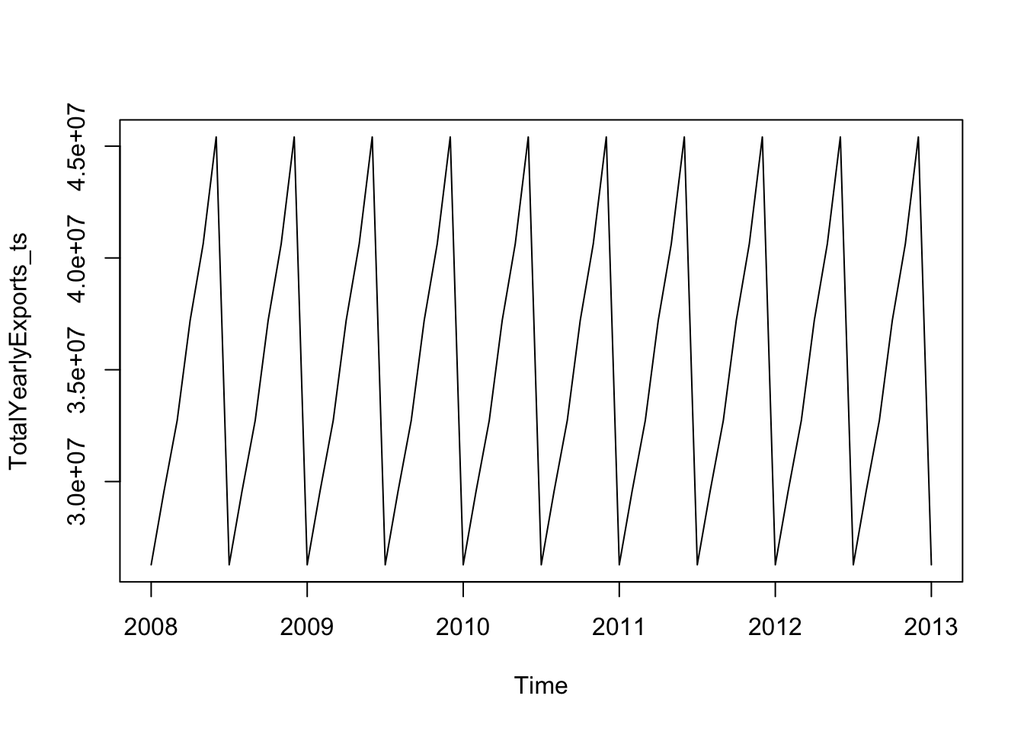

```r
TotalYearlyExports_ts <- ts(TotalYearlyExports_vector, start=c(2008), end=c(2013), frequency=12)
plot.ts(TotalYearlyExports_ts)
```

3. We can notice the fluctuations over time are constant showing a definite seasonality. As a secondary reference we can transform the time series by calculating the natural log of the original data:

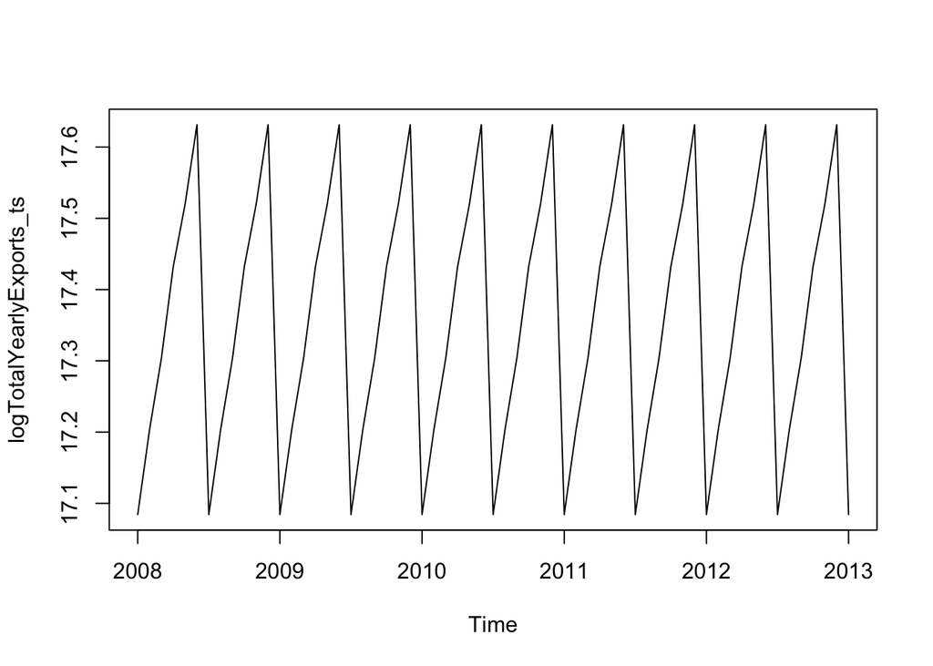

```r
logTotalYearlyExports_ts <- log(TotalYearlyExports_ts)
plot.ts(logTotalYearlyExports_ts)
```

## Decomposition

“Decomposing a time series means separating it into its constituent components, which are usually a trend component and an irregular component, and if it is a seasonal time series, a seasonal component.” https://a-little-book-of-r-for-time-series.readthedocs.io/en/latest/src/timeseries.html

1. The next steps will be to use a basic decomposition to observe the trend cycle and seasonality of the data

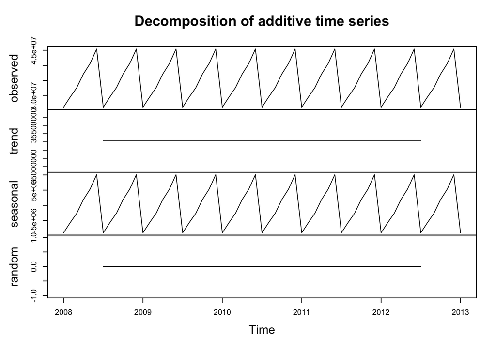

```r
decompose_TotalYearlyExports_ts <- decompose(TotalYearlyExports_ts)
plot(decompose_TotalYearlyExports_ts)
```

2. Observe the estimated values: The largest seasonal factor seems to occur aproximately every six months (June and Dec 10096695)

```r
decompose_TotalYearlyExports_ts$seasonal
```

```
##           Jan      Feb      Mar      Apr      May      Jun      Jul
## 2008 -9031704 -5701799 -2584943  1903788  5317961 10096695 -9031704
## 2009 -9031704 -5701799 -2584943  1903788  5317961 10096695 -9031704
## 2010 -9031704 -5701799 -2584943  1903788  5317961 10096695 -9031704
## 2011 -9031704 -5701799 -2584943  1903788  5317961 10096695 -9031704
## 2012 -9031704 -5701799 -2584943  1903788  5317961 10096695 -9031704
## 2013 -9031704
##           Aug      Sep      Oct      Nov      Dec
## 2008 -5701799 -2584943  1903788  5317961 10096695
## 2009 -5701799 -2584943  1903788  5317961 10096695
## 2010 -5701799 -2584943  1903788  5317961 10096695
## 2011 -5701799 -2584943  1903788  5317961 10096695
## 2012 -5701799 -2584943  1903788  5317961 10096695
## 2013
```

## Correlation of Imported Indicators

See if the results above support the imported indicators: Indicator chosen Chage in Export Prices.

```r
ChangeExportPrices <- tidyImportedIndicatorsChulwalar[1:12,]
ChangeExportPrices <- ChangeExportPrices[c(2:7)]
ChangeExportPrices
```

```
##    2008 2009  2010  2011  2012  2013
## 1  97.4 98.3  99.0 100.7 102.8 104.5
## 2  97.8 98.9  99.4 101.3 103.5 105.1
## 3  98.3 98.7  99.9 101.9 104.1 105.6
## 4  98.1 98.8 100.0 101.9 103.9 105.1
## 5  98.7 98.7  99.9 101.9 103.9 105.5
## 6  98.9 99.0  99.9 102.0 103.7 105.6
## 7  99.5 99.0 100.1 102.2 104.1 106.1
## 8  99.2 99.2 100.2 102.3 104.5 106.1
## 9  99.1 98.9 100.1 102.5 104.6 106.1
## 10 98.9 98.9 100.2 102.5 104.6 105.9
## 11 98.4 98.8 100.3 102.7 104.7 106.1
## 12 98.8 99.6 100.9 102.9 105.0 106.5
```

```r
ChangeExportPrices_ts <- ts(ChangeExportPrices, start=c(2008), end=c(2013), frequency=12)
```

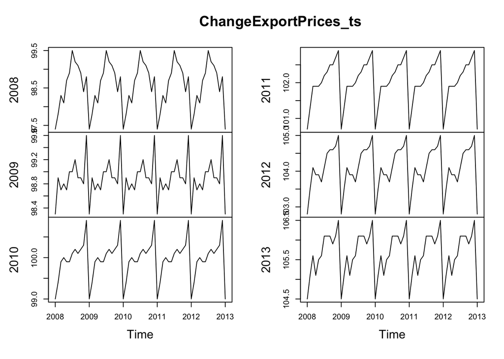

```r
plot.ts(ChangeExportPrices_ts)
```

## Proceed to Forecast

Install required pacakges:

```r
install.packages("forecast", repos="http://cran.us.r-project.org",dependencies=TRUE)
library(forecast)
```

**ARIMA forecasting model**

1. Build the ARIMA forecasting model: the arima function takes the time series data as an input, and parameters (p, d, q), defined as follows: p: The number of autoregressive terms d: The number of nonseasonal differences needed for stationarity q: The number of lagged forecast errors

   Some combinations are:

   (1,0,0): This series is generally used when the data is highly auto-correlated. Here, we predict the current value using its immediate preceding value. Usually, the current value will be predicted by multiplying the previous value with a multiplicative factor plus a constant.

   (2,0,0): In this case, the current value is predicted based on the preceding two values.

   (0,1,0): This is also called a random walk model, where there is neither seasonality nor can the previous value predict the current value.

   (1,1,0): This case is used when the random walk model has a drift that can be defined by the previous value.

   (0,1,1): This method can be used when there is no seasonality or trend in the data. This is also called the simple exponential smoothening method. In this case, the error of the random walk is offset by the smoothening of the previous value.

```r
a_model=arima(as.matrix(TotalYearlyExports_ts), order=c(2,0,0))
```

2. Forecast: pass the arima model itself as a parameter to the forecast function, we also need to pass the number of future values that has to be predicted.

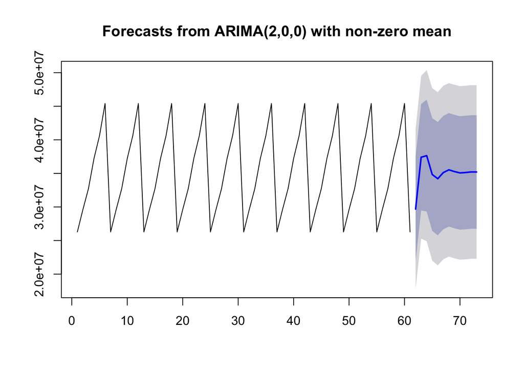

```r
aforecast=forecast.Arima(a_model,h=12)
plot(aforecast)
```

3. Conclusions: We chose model 2,0,0 as seasonality is highly evident in the data and think this model is more apropiate than others. For example when we try to see how simple exponential smoothening model will look we notice forecasted numbers appear to be less accurate: [We keep tweaking the parameters to improve accuracy].

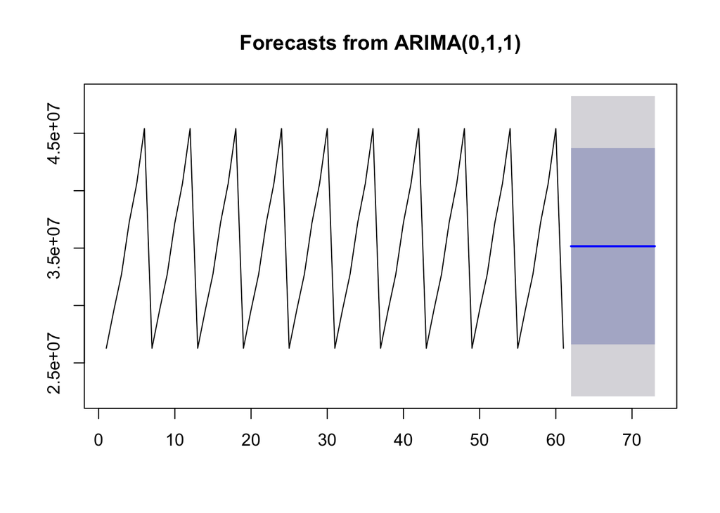

```r
a_model=arima(as.matrix(TotalYearlyExports_ts), order=c(0,1,1))
aforecast=forecast.Arima(a_model,h=12)
plot(aforecast)
```

**Holt-Winters method**

1. The HoltWinters function requires a given time series data, and the following parameters:

   alpha: The parameter of the Holt-Winters filters

   beta: This is used for the trend component; when set to false, the function will do exponential smoothening

   gamma: This is used for the seasonal component; when set to false, the nonseasonal component is fitted
2. Here again we buil the model we think is more appropiate, in which case setting beta=TRUE to avoid doing exponential smoothering.

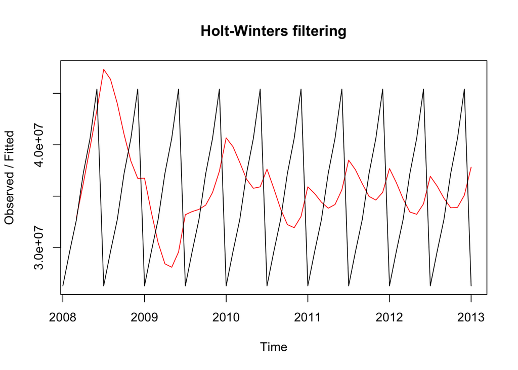

```r
h_model=HoltWinters(TotalYearlyExports_ts, beta=TRUE, gamma=FALSE)
plot(h_model)
```

3. Forecast: We pass the model that ww built to the predict function. Other parameters are: the period (for which the prediction has to be made), prediction.interval (when set to true, the lower and upper bounds of the corresponding prediction intervals are computed), and level (which is the confidence interval for the prediction).

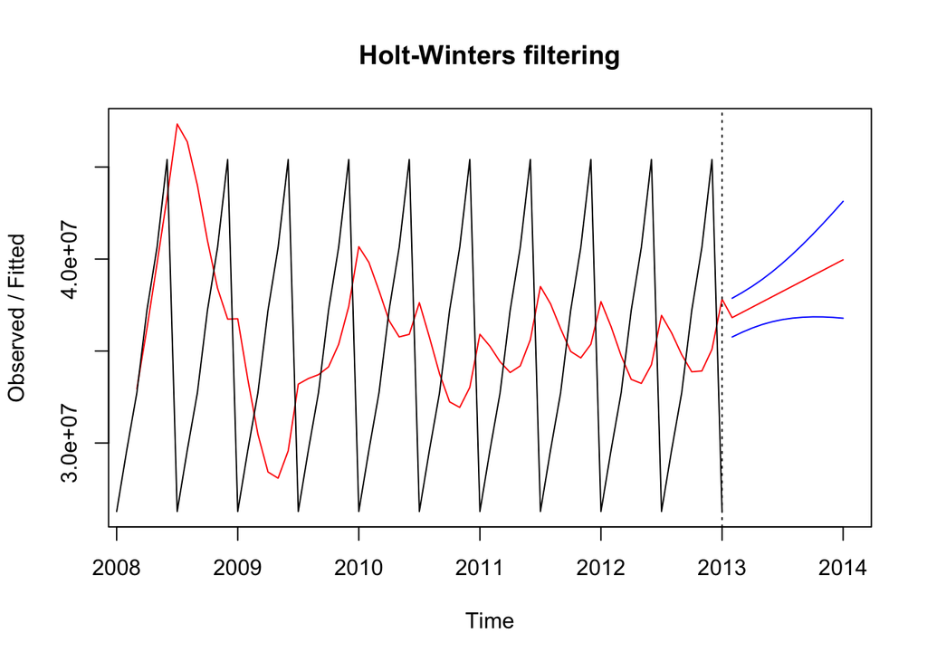

```r
forecast <- predict(h_model, n.ahead = 12, prediction.interval = T, level = 0.1)
plot(h_model, forecast)
```

4. Conclusion: Our chosen model looks off. It looks like after all we might need to adjust the gamma value. We decided to try one more time and notice this second attempt is more in line with historical data [We keep tweaking the parameters to improve accuracy]:

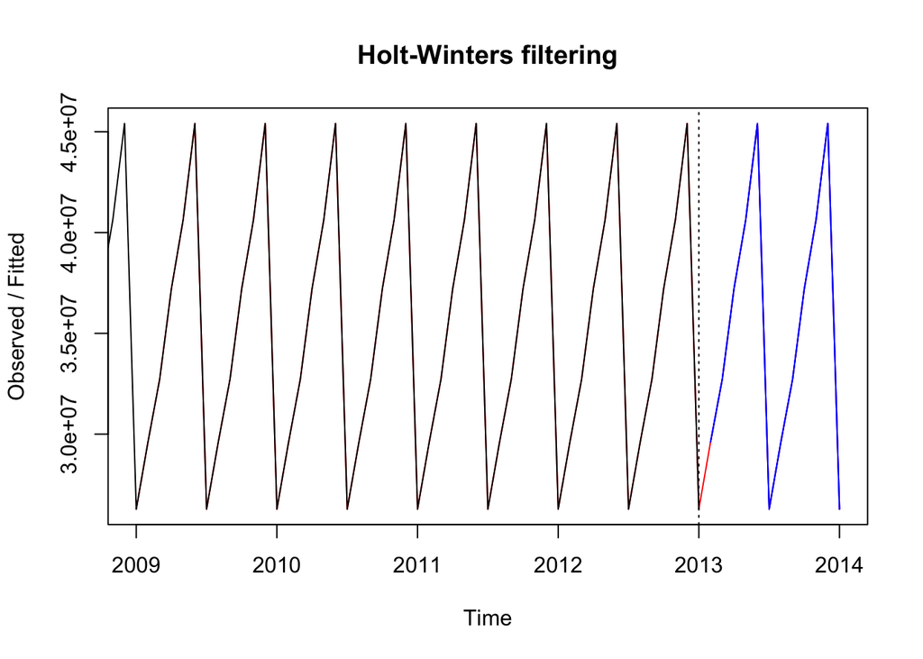

```r
h_model=HoltWinters(TotalYearlyExports_ts, beta=TRUE, gamma=0.1)
forecast <- predict(h_model, n.ahead = 12, prediction.interval = T, level = 0.1)
plot(h_model, forecast)
```

5. See actual forcasted values:

```r
hforecast <- as.data.frame(forecast)
forecast_exports <- hforecast$fit
forecast_exports <- as.data.frame(forecast_exports)
head(forecast_exports, 10)
```

```
##    forecast_exports
## 1          29609916
## 2          32726772
## 3          37215503
## 4          40629676
## 5          45408410
## 6          26280011
## 7          29609916
## 8          32726772
## 9          37215503
## 10         40629676
```

**Simple Exponential Smothing**

“Forecasts produced using simple exponential smoothing methods are weighted averages of past observations, with the weights decaying exponentially as the observations get older”.

https://www.otexts.org/fpp/7

1. First: try the model with an alpha smoothing parameter of 0.8
2. Second: try the model with an alpha smoothing parameter of 0.6
3. Third: all defaults

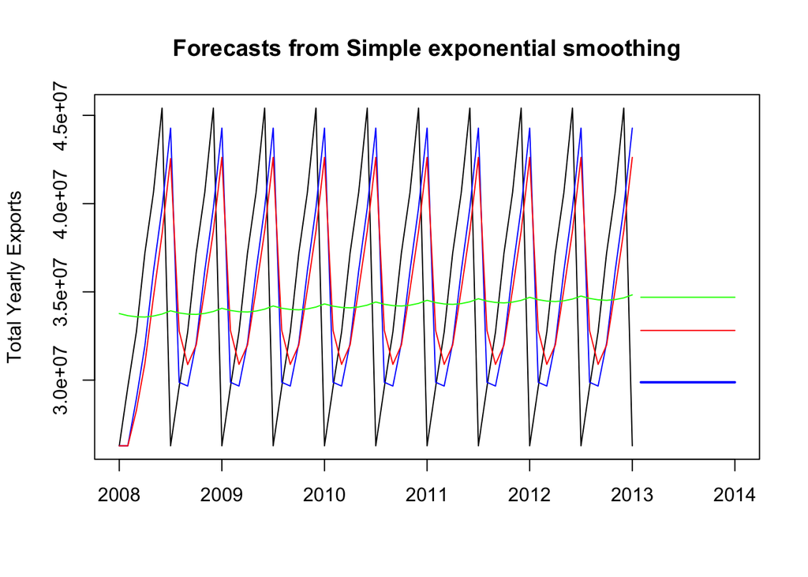

```r
fit1 <- ses(TotalYearlyExports_ts, alpha=0.8, beta=0.2, initial="simple", h=12)
fit2 <- ses(TotalYearlyExports_ts, alpha=0.6, beta=0.2, initial="simple", h=12 )
fit3 <- ses(TotalYearlyExports_ts, h=12 )
plot(fit1, plot.conf=FALSE, ylab="Total Yearly Exports")
lines(fitted(fit1), col="blue")
lines(fitted(fit2), col="red")
lines(fitted(fit3), col="green")
lines(fit1$mean, col="blue")
lines(fit2$mean, col="red")
lines(fit3$mean, col="green")
```

Here the actual predicted values: Defaults (green) gives us more optimistics values.

```r
fit1$mean
```

```
##           Jan      Feb      Mar      Apr      May      Jun      Jul
## 2013          29879066 29879066 29879066 29879066 29879066 29879066
## 2014 29879066
##           Aug      Sep      Oct      Nov      Dec
## 2013 29879066 29879066 29879066 29879066 29879066
## 2014
```

```r
fit2$mean
```

```
##           Jan      Feb      Mar      Apr      May      Jun      Jul
## 2013          32814564 32814564 32814564 32814564 32814564 32814564
## 2014 32814564
##           Aug      Sep      Oct      Nov      Dec
## 2013 32814564 32814564 32814564 32814564 32814564
## 2014
```

```r
fit3$mean
```

```
##           Jan      Feb      Mar      Apr      May      Jun      Jul
## 2013          34694426 34694426 34694426 34694426 34694426 34694426
## 2014 34694426
##           Aug      Sep      Oct      Nov      Dec
## 2013 34694426 34694426 34694426 34694426 34694426
## 2014
```

**Holt’s Linear Trend Method**

This method allows for forecasting data with a trend. The trend component observed in the historical data is pretty flat so we decided to try this model at the very last. It also uses alpha as smoothing parameter for the level and beta as the smoothing parameter for the trend. It can be either additive or exponential.

1. First: try additive model with a smoothing parameter of 0.8
2. Second: try an exponential model with a smoothing parameter of 0.6
3. Third: all defaults

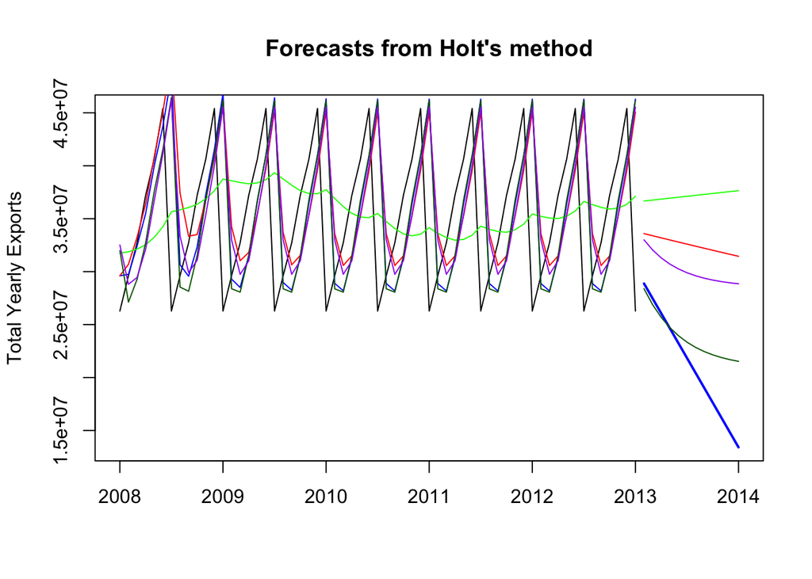

```r
fit1 <- holt(TotalYearlyExports_ts, alpha=.8, beta=0.2, initial="simple", h=12)
fit2 <- holt(TotalYearlyExports_ts, alpha=.6, beta=0.2, initial="simple", exponential=TRUE, h=12 )
fit3 <- holt(TotalYearlyExports_ts, h=12 )
plot(fit1, plot.conf=FALSE, ylab="Total Yearly Exports")
lines(fitted(fit1), col="blue")
lines(fitted(fit2), col="red")
lines(fitted(fit3), col="green")
lines(fit1$mean, col="blue")
lines(fit2$mean, col="red")
lines(fit3$mean, col="green")
fit4 <- holt(TotalYearlyExports_ts, alpha=.8, beta=0.2, damped=TRUE, initial="simple", h=12)
lines(fitted(fit4), col="darkgreen")
lines(fit4$mean, col="darkgreen")
fit5 <- holt(TotalYearlyExports_ts, alpha=.6, beta=0.2, damped=TRUE, initial="simple", exponential=TRUE, h=12 )
lines(fitted(fit5), col="purple")
lines(fit5$mean, col="purple")
```

4. Conclusion: As we could observed (and had expected), there is no trend really defined, or one that could be forecast using this model. Since the historical data shows seasonality component rather than a trend.

Here the actual predicted values: Notice that both, additive and exponential models propose a negative trend.

```r
fit1$mean
```

```
##           Jan      Feb      Mar      Apr      May      Jun      Jul
## 2013          28876333 27469987 26063641 24657295 23250950 21844604
## 2014 13406529
##           Aug      Sep      Oct      Nov      Dec
## 2013 20438258 19031912 17625567 16219221 14812875
## 2014
```

```r
fit2$mean
```

```
##           Jan      Feb      Mar      Apr      May      Jun      Jul
## 2013          33593471 33392594 33192918 32994437 32797142 32601027
## 2014 31448720
##           Aug      Sep      Oct      Nov      Dec
## 2013 32406085 32212309 32019691 31828225 31637904
## 2014
```

```r
fit3$mean
```

```
##           Jan      Feb      Mar      Apr      May      Jun      Jul
## 2013          36671249 36760439 36849629 36938818 37028008 37117197
## 2014 37652334
##           Aug      Sep      Oct      Nov      Dec
## 2013 37206387 37295576 37384766 37473955 37563145
## 2014
```

```r
fit4$mean
```

```
##           Jan      Feb      Mar      Apr      May      Jun      Jul
## 2013          28381873 26882041 25682177 24722285 23954371 23340040
## 2014 21526889
##           Aug      Sep      Oct      Nov      Dec
## 2013 22848575 22455404 22140866 21889236 21687932
## 2014
```

```r
fit5$mean
```

```
##           Jan      Feb      Mar      Apr      May      Jun      Jul
## 2013          33002671 32046772 31302026 30718710 30259894 29897780
## 2014 28854100
##           Aug      Sep      Oct      Nov      Dec
## 2013 29611211 29383935 29203370 29059718 28945305
## 2014
```

**Damp Trend Method**

Often the single-most accurate forecasting method for seasonal data!

**Damped Linear Method** It can be additive or exponentially (less conservative), and includes a damp paremeter.

Here is the code we used for the damped version:

fit4 <- holt(TotalYearlyExports_ts, alpha=.8, beta=0.2, damped=TRUE, initial=“simple”, h=12) lines(fitted(fit4), col=“darkgreen”) fit4$mean lines(fit3$mean, col=“green”)

fit5 <- holt(TotalYearlyExports_ts, alpha=.6, beta=0.2, damped=TRUE, initial=“simple”, exponential=TRUE, h=12 ) lines(fitted(fit5), col=“purple”) lines(fit5$mean, col="purple") fit5$mean

Conclusion: Fit5 model is slightly better but not quite convincing when compared against historical data.

**Accuracy**

1. Compare the different the models:

```r
fit1$model
```

```
## Holt's method
##
## Call:
##  holt(x = TotalYearlyExports_ts, h = 12, initial = "simple", alpha = 0.8,
##
##  Call:
##      beta = 0.2)
##
##   Smoothing parameters:
##     alpha = 0.8
##     beta  = 0.2
##
##   Initial states:
##     l = 26280011
##     b = 3329905
##
##   sigma:  9014603
```

```r
fit2$model
```

```
## Holt's method with exponential trend
##
## Call:
##  holt(x = TotalYearlyExports_ts, h = 12, initial = "simple", exponential = TRUE,
##
##  Call:
##      alpha = 0.6, beta = 0.2)
##
##   Smoothing parameters:
##     alpha = 0.6
##     beta  = 0.2
##
##   Initial states:
##     l = 26280011
##     b = 1.1267
##
##   sigma:  0.2091
```

```r
fit3$model
```

```
## Holt's method
##
## Call:
##  holt(x = TotalYearlyExports_ts, h = 12)
##
##   Smoothing parameters:
##     alpha = 0.0497
##     beta  = 0.0205
##
##   Initial states:
##     l = 31216068.5903
##     b = 523612.6618
##
##   sigma:  6985125
##
##      AIC     AICc      BIC
## 2181.397 2182.111 2189.841
```

```r
fit4$model
```

```
## Damped Holt's method
##
## Call:
##  holt(x = TotalYearlyExports_ts, h = 12, damped = TRUE, initial = "simple",
##
##  Call:
##      alpha = 0.8, beta = 0.2)
##
##   Smoothing parameters:
##     alpha = 0.8
##     beta  = 0.2
##     phi   = 0.8
##
##   Initial states:
##     l = 31216069.0517
##     b = 958394.2718
##
##   sigma:  8936314
##
##      AIC     AICc      BIC
## 2209.451 2209.872 2215.783
```

```r
fit5$model
```

```
## Damped Holt's method with exponential trend
##
## Call:
##  holt(x = TotalYearlyExports_ts, h = 12, damped = TRUE, initial = "simple",
##
##  Call:
##      exponential = TRUE, alpha = 0.6, beta = 0.2)
##
##   Smoothing parameters:
##     alpha = 0.6
##     beta  = 0.2
##     phi   = 0.8
##
##   Initial states:
##     l = 31222778.2224
##     b = 1.0521
##
##   sigma:  0.2142
##
##      AIC     AICc      BIC
## 2189.185 2189.606 2195.518
```

2. Verify accuracy against historical data:

```r
accuracy(fit1, TotalYearlyExports_vector)
```

```
##                     ME     RMSE      MAE       MPE     MAPE      MASE
## Training set -485271.6  9014603  6320774 -5.272938 20.60878 0.9913178
## Test set     9951246.4 13358513 10816687 24.353096 27.64625 1.6964337
##                     ACF1
## Training set -0.06052178
## Test set              NA
```

```r
accuracy(fit2, TotalYearlyExports_vector)
```

```
##                    ME    RMSE     MAE       MPE     MAPE      MASE
## Training set -1241747 8908094 6639236 -7.912605 21.45472 1.0412637
## Test set      2216450 7201940 6070544  2.799430 16.80889 0.9520731
##                    ACF1
## Training set 0.06702163
## Test set             NA
```

```r
accuracy(fit3, TotalYearlyExports_vector)
```

```
##                      ME    RMSE     MAE       MPE     MAPE      MASE
## Training set  -347662.7 6985125 6047879 -4.707081 18.08399 0.9485183
## Test set     -1582508.6 6556149 5639031 -8.070011 17.35911 0.8843967
##                   ACF1
## Training set 0.1776038
## Test set            NA
```

```r
accuracy(fit4, TotalYearlyExports_vector)
```

```
##                   ME     RMSE      MAE      MPE     MAPE     MASE
## Training set -145153  8936314  6570674 -4.20460 21.35029 1.030511
## Test set     9817917 12797426 10518538 24.32535 26.99133 1.649673
##                    ACF1
## Training set -0.0822064
## Test set             NA
```

```r
accuracy(fit5, TotalYearlyExports_vector)
```

```
##                     ME    RMSE     MAE       MPE     MAPE     MASE
## Training set -575254.3 8951861 6982417 -5.973255 22.35146 1.095086
## Test set     4107072.6 8597312 7160245  7.946777 19.21703 1.122976
##                    ACF1
## Training set 0.04994958
## Test set             NA
```

3. Conclusion: Our previous findings match those obtained with the accuracy results. Notice F3(defaults) has the lowest values for ERROR in the testing Set. Also Fit5(Damped Holt’s method with exponential trend) seems to have pretty low values.

**Holt Winter Seasonal Method**

This method also offers a damped version and it can be additive (seasonal variations roughly constant through the series) or exponential (seasonal variations changing proportional to the level of series).

Lastly we would like to run the Holt Winter Seasonal Method but using the hw function as seen in the module 9 videos.

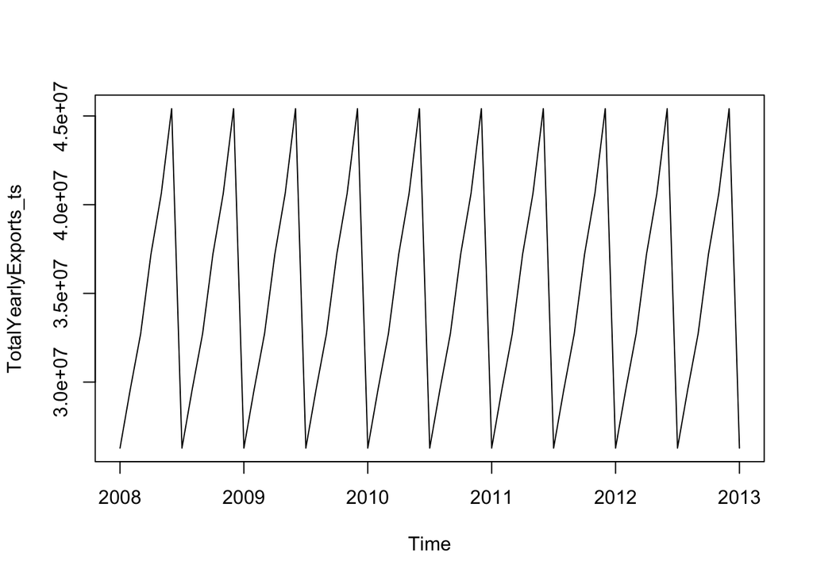

```r
plot(TotalYearlyExports_ts, type="l")
```

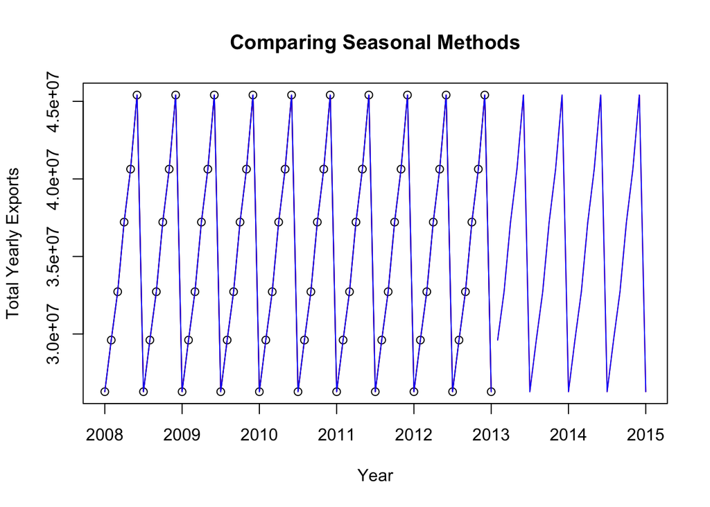

```r
fit1 <- hw(TotalYearlyExports_ts, seasonal="additive")
fit2 <- hw(TotalYearlyExports_ts, seasonal="multiplicative")
plot(fit2, ylab="Total Yearly Exports", plot.conf=FALSE, type="o", fcol="white", xlab="Year", main = "Comparing Seasonal Methods")
lines(fitted(fit1), col="red")
lines(fitted(fit2), col="blue")
lines(fit1$mean, col="red")
lines(fit2$mean, col="blue")
```

```r
fit1$mean
```

```
##           Jan      Feb      Mar      Apr      May      Jun      Jul
## 2013          29609916 32726772 37215503 40629676 45408410 26280011
## 2014 26280011 29609916 32726772 37215503 40629676 45408410 26280011
## 2015 26280011
##           Aug      Sep      Oct      Nov      Dec
## 2013 29609916 32726772 37215503 40629676 45408410
## 2014 29609916 32726772 37215503 40629676 45408410
## 2015
```

```r
fit2$mean
```

```
##           Jan      Feb      Mar      Apr      May      Jun      Jul
## 2013          29609916 32726772 37215503 40629676 45408410 26280011
## 2014 26280011 29609916 32726772 37215503 40629676 45408410 26280011
## 2015 26280011
##           Aug      Sep      Oct      Nov      Dec
## 2013 29609916 32726772 37215503 40629676 45408410
## 2014 29609916 32726772 37215503 40629676 45408410
## 2015
```

```r
accuracy(fit1)
```

```
##                         ME         RMSE          MAE           MPE
## Training set -2.748165e-09 8.782033e-09 3.236728e-09 -9.035265e-15
##                      MAPE MASE      ACF1
## Training set 1.011119e-14  Inf 0.2139382
```

```r
accuracy(fit2)
```

```
##                         ME         RMSE          MAE           MPE
## Training set -4.641345e-09 1.385691e-08 6.595596e-09 -1.299667e-14
##                      MAPE MASE       ACF1
## Training set 1.875933e-14  Inf -0.1895224
```

**Comparing vs Planned Data**

```r
forecast_exports
```

```
##    forecast_exports
## 1          29609916
## 2          32726772
## 3          37215503
## 4          40629676
## 5          45408410
## 6          26280011
## 7          29609916
## 8          32726772
## 9          37215503
## 10         40629676
## 11         45408410
## 12         26280011
```

4. Looking at our actual predicted values using Holt Winters Multiplicative with Seasonal Component:

```r
fitted(fit2)
```

```
##           Jan      Feb      Mar      Apr      May      Jun      Jul
## 2008 26280011 29609916 32726772 37215503 40629676 45408410 26280011
## 2009 26280011 29609916 32726772 37215503 40629676 45408410 26280011
## 2010 26280011 29609916 32726772 37215503 40629676 45408410 26280011
## 2011 26280011 29609916 32726772 37215503 40629676 45408410 26280011
## 2012 26280011 29609916 32726772 37215503 40629676 45408410 26280011
## 2013 26280011
##           Aug      Sep      Oct      Nov      Dec
## 2008 29609916 32726772 37215503 40629676 45408410
## 2009 29609916 32726772 37215503 40629676 45408410
## 2010 29609916 32726772 37215503 40629676 45408410
## 2011 29609916 32726772 37215503 40629676 45408410
## 2012 29609916 32726772 37215503 40629676 45408410
## 2013
```

5. Compare to Planned Exports

```r
tidyImportedPlanDataChulwalar
```

```
##                  TotalPlan     2008     2009     2010     2011     2012
## 1                      Jan  2243103  2547980  2965885  3113110  3895396
## 2                      Feb  2162705  2247049  2751170  2883766  3588151
## 3                      Mar  2720911  2731156  2906493  2957893  3787240
## 4                      Apr  2011182  2020158  2383358  2601648  3036434
## 5                      May  1877757  2098038  2246893  2370949  2907891
## 6                      Jun  1819924  1927995  1992851  2339881  2707822
## 7                      Jul  1682196  1783692  2023434  2105328  2619486
## 8                      Aug  1893171  1907705  2244997  2341623  3784557
## 9                      Sep  3325711  3124040  3257717  4086297  4987460
## 10                     Oct  2662148  3102251  3536338  3640827  4367319
## 11                     Nov  2909966  3154669  3358206  3502334  4205772
## 12                     Dec  2574633  2742367  3112906  3280476  4059533
## 13                               NA       NA       NA       NA       NA
## 14             Coffee Plan     2008     2009     2010     2011     2012
```

[output cut: 179 more lines]

```r
TotalYearlyExports_Planned <- tidyImportedPlanDataChulwalar[84:97,]
TotalYearlyExports_Planned <- TotalYearlyExports_Planned[c(1:7)]
TotalYearlyExports_Planned
```

```
##                  TotalPlan     2008     2009     2010     2011     2012
## 84 Total yearly sales Plan     2008     2009     2010     2011     2012
## 85                     Jan 27883407 29387100 32780247 35224132 43947063
## 86                     Feb 27883407 29387100 32780247 35224132 43947063
## 87                     Mar 27883407 29387100 32780247 35224132 43947063
## 88                     Apr 27883407 29387100 32780247 35224132 43947063
## 89                     May 27883407 29387100 32780247 35224132 43947063
## 90                     Jun 27883407 29387100 32780247 35224132 43947063
## 91                     Jul 27883407 29387100 32780247 35224132 43947063
## 92                     Aug 27883407 29387100 32780247 35224132 43947063
## 93                     Sep 27883407 29387100 32780247 35224132 43947063
## 94                     Oct 27883407 29387100 32780247 35224132 43947063
## 95                     Nov 27883407 29387100 32780247 35224132 43947063
## 96                     Dec 27883407 29387100 32780247 35224132 43947063
## NA                    <NA>       NA       NA       NA       NA       NA
##        2013
## 84     2013
## 85 44152007
## 86 44152007
## 87 44152007
## 88 44152007
## 89 44152007
## 90 44152007
## 91 44152007
## 92 44152007
## 93 44152007
## 94 44152007
## 95 44152007
## 96 44152007
## NA       NA
```

```r
TotalYearlyExports_Planned_vector <- c(27883407,29387100,32780247,35224132,43947063,44152007)
TotalYearlyExports_Planned_vector
```

```
## [1] 27883407 29387100 32780247 35224132 43947063 44152007
```

6. Plot Actual Planned vs Forecast

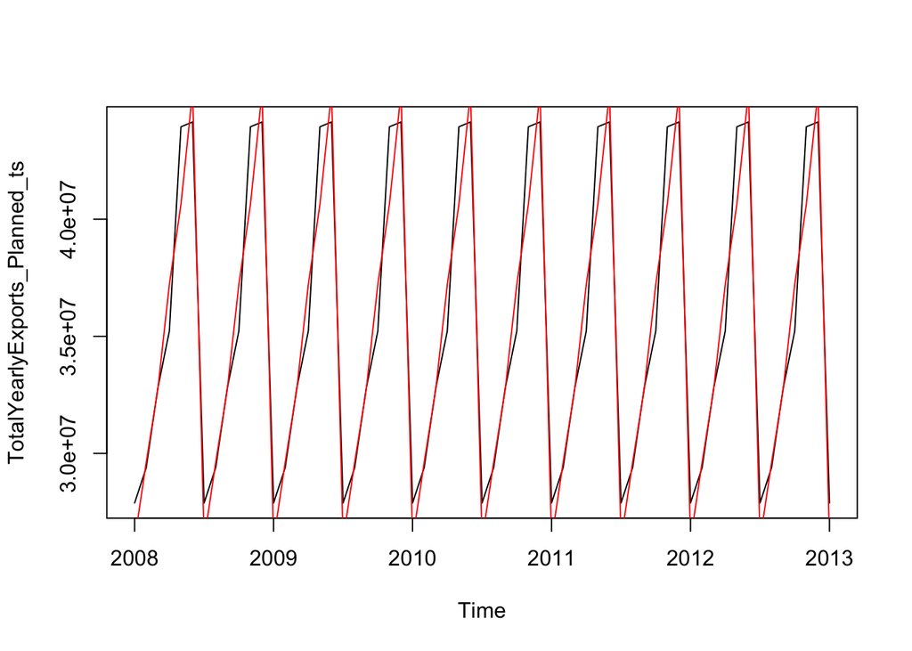

```r
TotalYearlyExports_Planned_ts <- ts(TotalYearlyExports_Planned_vector, start=c(2008), end=c(2013), frequency=12)
plot.ts(TotalYearlyExports_Planned_ts)
lines(fitted(fit2), col="red")
```

******************************

7. Coclusion: Holt Winters Multiplicative with Seasonal Component is our best model. Its Forecast values, although a bit more positive, are much closer to those planned.

```r
fit2$model
```

```
## Holt-Winters' multiplicative method
##
## Call:
##  hw(x = TotalYearlyExports_ts, seasonal = "multiplicative")
##
##   Smoothing parameters:
##     alpha = 0.0418
##     beta  = 0.0043
##     gamma = 0.8636
##
##   Initial states:
##     l = 35311714.6667
##     b = 0
##     s=1.2859 1.1506 1.0539 0.9268 0.8385 0.7442
##            1.2859 1.1506 1.0539 0.9268 0.8385 0.7442
##
##   sigma:  0
##
##       AIC      AICc       BIC
## -1926.392 -1914.028 -1892.618
```

**Additional Anaylisis**

After conducting and observing a birds eye view of Total yearly Exports, we dive into a more specific analysis under the Wuge Flower and investigate Planned versus Actual. As well as, introducing the National Holiday Indicator to account for the cultural aspect.

Further analysis on this case can be found on https://github.com/kkillion43/Unit10CaseStudy2

*R Data Science Essentials, Ravindran Sharan Kumar, Raja B. Koushik, Packt Publishing, January 2016*